# RETRASCORE: mortalidad y exactitud por puntuacion y ano

Reproduccion del punto 6 con cohorte_retrascore.rds

2026-09-18

# 6. Mortalidad y exactitud de clasificacion por RETRASCORE y ano

El analisis utiliza directamente `cohorte_retrascore.rds`. Como el archivo no incluye una columna de puntuacion RETRASCORE, esta se reconstruye a partir de sus componentes segun el articulo original: cada coeficiente publicado se multiplica por 2 y se redondea al entero mas cercano. La probabilidad de muerte se calcula con la ecuacion logistica publicada, sin reestimar coeficientes.

La mortalidad se define como la proporcion de muertes a 30 dias entre los casos con desenlace conocido. La exactitud es la proporcion de pacientes cuya clase predicha coincide con el desenlace observado, usando probabilidad de muerte `>= params$probability_cutoff` para predecir muerte.

```r
edad <- as.character(cohorte$edad_categoria)
pupilas <- as.character(cohorte$pupilas)

componentes_puntos <- data.frame(
  edad = ifelse(
    is.na(edad), NA_integer_,
    c("<50" = 0L, "50-65" = 1L, "66-75" = 2L, ">75" = 4L)[edad]
  ),
  precoag = comprobar_binaria(cohorte$precoag, "precoag"),
  iot_prehospitalaria = comprobar_binaria(
    cohorte$iot_prehospitalaria, "iot_prehospitalaria"
  ),
  mecanismo_alto_riesgo = comprobar_binaria(
    cohorte$mecanismo_alto_riesgo, "mecanismo_alto_riesgo"
  ),
  pupilas = ifelse(
    is.na(pupilas), NA_integer_,
    c("normal" = 0L, "midriasis unilateral" = 2L,
      "midriasis bilateral" = 6L)[pupilas]
  ),
  gcs_menor_igual_8 = 2L * comprobar_binaria(
    cohorte$gcs_menor_igual_8, "gcs_menor_igual_8"
  ),
  mais_cabeza = comprobar_binaria(cohorte$mais_cabeza, "mais_cabeza"),
  mais_torax = -comprobar_binaria(cohorte$mais_torax, "mais_torax"),
  fallo_hemodinamico = 2L * comprobar_binaria(
    cohorte$fallo_hemodinamico, "fallo_hemodinamico"
  ),
  fallo_respiratorio = comprobar_binaria(
    cohorte$fallo_respiratorio, "fallo_respiratorio"
  ),
  coagulopatia_24h = comprobar_binaria(
    cohorte$coagulopatia_24h, "coagulopatia_24h"
  ),
  ventilacion_mecanica = comprobar_binaria(
    cohorte$ventilacion_mecanica, "ventilacion_mecanica"
  ),
  hemorragia_masiva = comprobar_binaria(
    cohorte$hemorragia_masiva, "hemorragia_masiva"
  )
)

componentes_modelo <- data.frame(
  edad_50_65 = ifelse(is.na(edad), NA_integer_, edad == "50-65"),
  edad_66_75 = ifelse(is.na(edad), NA_integer_, edad == "66-75"),
  edad_mayor_75 = ifelse(is.na(edad), NA_integer_, edad == ">75"),
  precoag = componentes_puntos$precoag,
  iot_prehospitalaria = componentes_puntos$iot_prehospitalaria,
  mecanismo_alto_riesgo = componentes_puntos$mecanismo_alto_riesgo,
  midriasis_unilateral = ifelse(
    is.na(pupilas), NA_integer_, pupilas == "midriasis unilateral"
  ),
  midriasis_bilateral = ifelse(
    is.na(pupilas), NA_integer_, pupilas == "midriasis bilateral"
  ),
  gcs_menor_igual_8 = cohorte$gcs_menor_igual_8,
  mais_cabeza = cohorte$mais_cabeza,
  mais_torax = cohorte$mais_torax,
  fallo_hemodinamico = cohorte$fallo_hemodinamico,
  fallo_respiratorio = cohorte$fallo_respiratorio,
  coagulopatia_24h = cohorte$coagulopatia_24h,
  ventilacion_mecanica = cohorte$ventilacion_mecanica,
  hemorragia_masiva = cohorte$hemorragia_masiva
)

casos_completos <- stats::complete.cases(componentes_modelo)
retrascore <- rep(NA_integer_, nrow(cohorte))
retrascore[casos_completos] <- rowSums(componentes_puntos[casos_completos, ])

puntuaciones_menores_14 <- sort(unique(retrascore[!is.na(retrascore) & retrascore < 14]))
niveles_retrascore <- c(as.character(puntuaciones_menores_14), "14+")
retrascore_grupo <- factor(
  ifelse(
    is.na(retrascore),
    NA_character_,
    ifelse(retrascore >= 14, "14+", as.character(retrascore))
  ),
  levels = niveles_retrascore,
  ordered = TRUE
)

predictor_lineal <- rep(NA_real_, nrow(cohorte))
predictor_lineal[casos_completos] <- with(
  componentes_modelo[casos_completos, ],
  -5.432 +
    0.598 * edad_50_65 + 1.239 * edad_66_75 + 2.198 * edad_mayor_75 +
    0.349 * precoag + 0.336 * iot_prehospitalaria +
    0.662 * mecanismo_alto_riesgo + 0.950 * midriasis_unilateral +
    3.217 * midriasis_bilateral + 0.841 * gcs_menor_igual_8 +
    0.495 * mais_cabeza - 0.271 * mais_torax +
    1.148 * fallo_hemodinamico + 0.708 * fallo_respiratorio +
    0.567 * coagulopatia_24h + 0.580 * ventilacion_mecanica +
    0.452 * hemorragia_masiva
)

probabilidad_muerte <- stats::plogis(predictor_lineal)
muerte_predicha <- ifelse(
  is.na(probabilidad_muerte), NA_integer_,
  as.integer(probabilidad_muerte >= params$probability_cutoff)
)

resultado_paciente <- data.frame(
  fila_fuente = seq_len(nrow(cohorte)),
  ano = cohorte$ano_trauma,
  muerte_30d = cohorte$mortalidad_30d,
  retrascore = retrascore,
  retrascore_grupo = retrascore_grupo,
  probabilidad_muerte = probabilidad_muerte,
  muerte_predicha = muerte_predicha,
  clasificacion_correcta = ifelse(
    is.na(cohorte$mortalidad_30d) | is.na(muerte_predicha),
    NA_integer_,
    as.integer(cohorte$mortalidad_30d == muerte_predicha)
  )
)

utils::write.csv(
  resultado_paciente,
  file.path(directorio_salida, "retrascore_resultado_por_paciente.csv"),
  row.names = FALSE,
  na = ""
)
```

```r
validos <- !is.na(resultado_paciente$retrascore_grupo) & !is.na(resultado_paciente$ano)
partes <- split(
  resultado_paciente[validos, , drop = FALSE],
  interaction(
    resultado_paciente$retrascore_grupo[validos],
    resultado_paciente$ano[validos],
    drop = TRUE
  )
)

if (!length(partes)) {
  stop("No hay registros con RETRASCORE y ano utilizables.")
}

filas_resumen <- lapply(partes, function(d) {
  desenlace_conocido <- !is.na(d$muerte_30d)
  exactitud_evaluable <- !is.na(d$clasificacion_correcta)
  data.frame(
    retrascore = d$retrascore_grupo[1],
    ano = d$ano[1],
    pacientes_n = nrow(d),
    desenlace_conocido_n = sum(desenlace_conocido),
    muertes_n = sum(d$muerte_30d == 1, na.rm = TRUE),
    mortalidad_porcentaje = if (any(desenlace_conocido)) {
      100 * mean(d$muerte_30d[desenlace_conocido] == 1)
    } else {
      NA_real_
    },
    exactitud_evaluable_n = sum(exactitud_evaluable),
    clasificaciones_correctas_n = sum(
      d$clasificacion_correcta == 1, na.rm = TRUE
    ),
    exactitud_porcentaje = if (any(exactitud_evaluable)) {
      100 * mean(d$clasificacion_correcta[exactitud_evaluable] == 1)
    } else {
      NA_real_
    }
  )
})

resumen_puntuacion_ano <- do.call(rbind, filas_resumen)
resumen_puntuacion_ano <- resumen_puntuacion_ano[
  order(resumen_puntuacion_ano$ano, resumen_puntuacion_ano$retrascore),
]
row.names(resumen_puntuacion_ano) <- NULL

utils::write.csv(
  resumen_puntuacion_ano,
  file.path(directorio_salida, "retrascore_resumen_puntuacion_ano.csv"),
  row.names = FALSE,
  na = ""
)

cat("Pacientes en el RDS original:", n_pacientes_rds_original, "\n")
```

```
## Pacientes en el RDS original: 17925
```

```r
cat("Pacientes excluidos por ano de trauma 2925:", n_excluidos_ano_2925, "\n")
```

```
## Pacientes excluidos por ano de trauma 2925: 1
```

```r
cat("Pacientes incluidos en el analisis:", nrow(cohorte), "\n")
```

```
## Pacientes incluidos en el analisis: 17924
```

```r
cat("Pacientes con RETRASCORE reconstruible:", sum(!is.na(retrascore)), "\n")
```

```
## Pacientes con RETRASCORE reconstruible: 16706
```

```r
cat("Rango observado de RETRASCORE antes de agrupar:", paste(range(retrascore, na.rm = TRUE), collapse = " a "), "\n")
```

```
## Rango observado de RETRASCORE antes de agrupar: -1 a 20
```

```r
cat("Categoria superior utilizada: 14+ puntos\n")
```

```
## Categoria superior utilizada: 14+ puntos
```

```r
cat("Anos observados:", paste(sort(unique(stats::na.omit(resultado_paciente$ano))), collapse = ", "), "\n")
```

```
## Anos observados: 2015, 2016, 2017, 2018, 2019, 2020, 2021, 2022, 2023, 2024, 2025
```

## 6.1. Mortalidad observada por RETRASCORE y ano

Cada celda representa la mortalidad observada a 30 dias entre los pacientes con desenlace conocido para esa puntuacion RETRASCORE y ese ano. El color representa el porcentaje de mortalidad y la etiqueta interior muestra el numero total de pacientes de la celda. Las puntuaciones de 14 o mas se agrupan como `14+`.

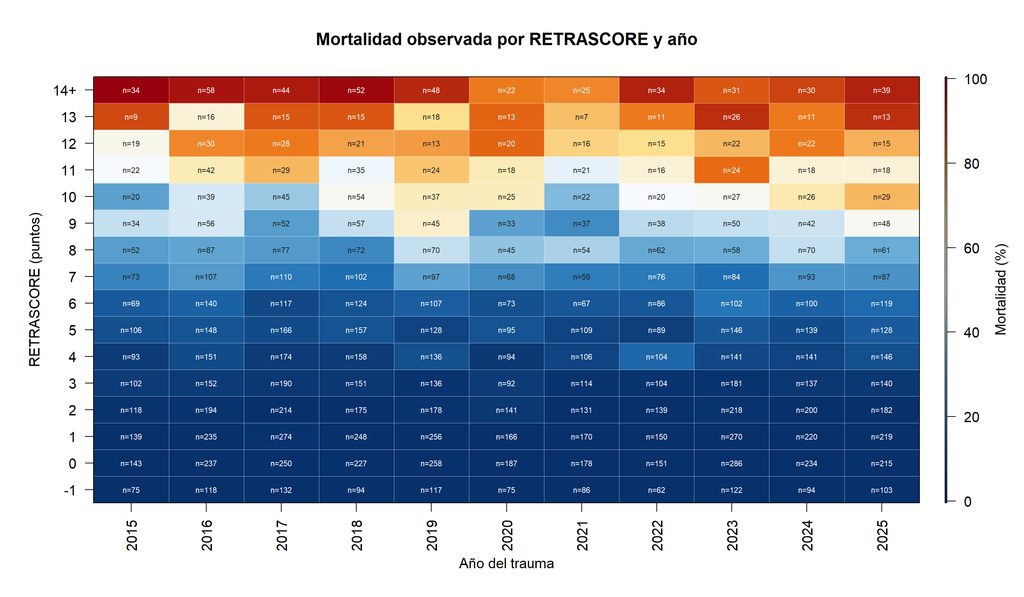

Mortalidad observada a 30 dias por puntuacion RETRASCORE y ano.

## 6.2. Exactitud de clasificacion por RETRASCORE y ano

Cada celda representa el porcentaje de clasificaciones correctas entre los pacientes con desenlace conocido y probabilidad calculable. El color representa la exactitud y la etiqueta interior muestra el numero total de pacientes de la celda. Las puntuaciones de 14 o mas se agrupan como `14+`. La muerte se predice cuando la probabilidad publicada es mayor o igual que 0.5.

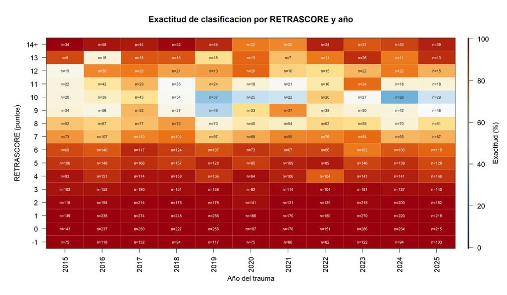

Exactitud de clasificacion por puntuacion RETRASCORE y ano.

## Notas de reproducibilidad

- No se imputan valores ausentes. Un RETRASCORE y una probabilidad solo se calculan cuando todos sus componentes estan disponibles.
- Las puntuaciones RETRASCORE de 14 o mas se presentan en una categoria comun `14+`; no se elimina ningun paciente por este agrupamiento.
- Se excluye el unico registro con ano de trauma 2925 por tratarse de un valor imposible. El archivo RDS original no se modifica.
- Los denominadores de mortalidad y exactitud se calculan por separado.